# Who Gets to be the Main Character? A Data Wrangling Tutorial

Grace Schneider

3.30.26

[figure not shown]

```r
# Load any R Packages you may need
library(tidyverse)
library(janitor)
library(ggplot2)
library(mosaic)
```

```r
# Load any datasets you may need

movies <- read_csv("movies.csv", show_col_types = FALSE) %>%
  rename(raw1 = 1, raw2 = 2, junk = 3) %>%
  select(-junk) %>%
  separate(
    raw1,
    into = c("name", "rating", "genre", "year", "released"),
    sep = ";",
    extra = "merge",
    fill = "right"
  ) %>%
  separate(
    raw2,
    into = c("country_info", "score", "votes", "director", "writer",
             "star", "country", "budget", "gross", "company", "runtime"),
    sep = ";",
    extra = "merge",
    fill = "right"
  ) %>%
  mutate(across(everything(), ~ str_remove_all(.x, '"'))) %>%
  mutate(
    year = as.numeric(year),
    score = as.numeric(score),
    votes = as.numeric(votes),
    budget = as.numeric(budget),
    gross = as.numeric(gross),
    runtime = as.numeric(runtime)
  ) %>%
  mutate(
    genre = str_trim(genre),
    rating = str_trim(rating)
  )
```

# What is Data Wrangling?

If you have ever seen a dataset and thought ‘this is a mess’ you know understand the purpose why data wrangling exists. Data wrangling is the process of transforming raw, messy data into something clean and structured enough to analyze. Real-world data almost never arrives in a format that is ready to use. Through this ‘how to’ we will be using a dataset of 4,000 Hollywood movies released between 1980 and 2001 to answer one guiding question: ‘Which actors dominated Hollywood as lead stars, and did starring in more movies actually lead to better-rated films?’

In other words, who keeps getting to be the main character, and is it deserved? Every wrangling step we take will be motivated by what we need to know next to answer that question. By the end, you’ll see the full pipeline, from raw data to a completed visualization!

# The Dataset

The data comes from [Kaggle](https://www.kaggle.com/datasets/ashishkumarjayswal/movies-dataset), originally sourced from IMDB. It contains one row per film with 15 variables covering the film’s title, cast, finances, and audiences rating.

# How To Data Wrangle

## Step 1: The Mess Before the Magic

When we load this dataset with the standard read.csv(), R misreads the file because it uses semicolons as separators instead of commas, and wraps values in extra quote characters. Rather than accepting a broken result, we can write our own custom function to handle it correctly. A function in R lets you package a set of steps and reuse them. Here we write parse_row() which uses three base R tools:

gsub() to strip out unwanted quote characters strsplit() to split each row at the semicolon trimws() to clean up any extra whitespace

We then apply it to every line of the raw file using lapply().

| name | rating | genre | year | released | score | votes | director | writer | star | country | budget | gross | company | runtime |
| --- | --- | --- | --- | --- | --- | --- | --- | --- | --- | --- | --- | --- | --- | --- |
| The Shining | R | Drama | 1980 | June 13, 1980 (United States) | 8.4 | 927000.0 | Stanley Kubrick | Stephen King | Jack Nicholson | United Kingdom | 19000000 | 46998772.0 | Warner Bros. | 146.0, |
| The Blue Lagoon | R | Adventure | 1980 | July 2, 1980 (United States) | 5.8 | 65000.0 | Randal Kleiser | Henry De Vere Stacpoole | Brooke Shields | United States | 4500000 | 58853106.0 | Columbia Pictures | 104.0, |
| Star Wars: Episode V - The Empire Strikes Back | PG | Action | 1980 | June 20, 1980 (United States) | 8.7 | 1200000.0 | Irvin Kershner | Leigh Brackett | Mark Hamill | United States | 18000000 | 538375067.0 | Lucasfilm | 124.0, |
| Airplane! | PG | Comedy | 1980 | July 2, 1980 (United States) | 7.7 | 221000.0 | Jim Abrahams | Jim Abrahams | Robert Hays | United States | 3500000 | 83453539.0 | Paramount Pictures | 88.0, |
| Caddyshack | R | Comedy | 1980 | July 25, 1980 (United States) | 7.3 | 108000.0 | Harold Ramis | Brian Doyle-Murray | Chevy Chase | United States | 6000000 | 39846344.0 | Orion Pictures | 98.0, |
| Friday the 13th | R | Horror | 1980 | May 9, 1980 (United States) | 6.4 | 123000.0 | Sean S. Cunningham | Victor Miller | Betsy Palmer | United States | 550000 | 39754601.0 | Paramount Pictures | 95.0, |
| The Blues Brothers | R | Action | 1980 | June 20, 1980 (United States) | 7.9 | 188000.0 | John Landis | Dan Aykroyd | John Belushi | United States | 27000000 | 115229890.0 | Universal Pictures | 133.0, |
| Raging Bull | R | Biography | 1980 | December 19, 1980 (United States) | 8.2 | 330000.0 | Martin Scorsese | Jake LaMotta | Robert De Niro | United States | 18000000 | 23402427.0 | Chartoff-Winkler Productions | 129.0, |
| Superman II | PG | Action | 1980 | June 19, 1981 (United States) | 6.8 | 101000.0 | Richard Lester | Jerry Siegel | Gene Hackman | United States | 54000000 | 108185706.0 | Dovemead Films | 127.0, |
| The Long Riders | R | Biography | 1980 | May 16, 1980 (United States) | 7.0 | 10000.0 | Walter Hill | Bill Bryden | David Carradine | United States | 10000000 | 15795189.0 | United Artists | 100.0, |

## Step 2: Marie Kondo Your Columns

Now that our data is properly structured, we can start shaping it for our analysis. select() lets you choose which columns to keep. Our question is about lead stars and their scores, so we don’t need every variable — things like writer, company, and released won’t help us answer it. Trimming down makes the dataset easier to read and work with. The rule of thumb –> only keep columns you’ll actually use!

| name | star | genre | year | score | budget | gross | rating |
| --- | --- | --- | --- | --- | --- | --- | --- |
| The Shining | Jack Nicholson | Drama | 1980 | 8.4 | 19000000 | 46998772.0 | R |
| The Blue Lagoon | Brooke Shields | Adventure | 1980 | 5.8 | 4500000 | 58853106.0 | R |
| Star Wars: Episode V - The Empire Strikes Back | Mark Hamill | Action | 1980 | 8.7 | 18000000 | 538375067.0 | PG |
| Airplane! | Robert Hays | Comedy | 1980 | 7.7 | 3500000 | 83453539.0 | PG |
| Caddyshack | Chevy Chase | Comedy | 1980 | 7.3 | 6000000 | 39846344.0 | R |
| Friday the 13th | Betsy Palmer | Horror | 1980 | 6.4 | 550000 | 39754601.0 | R |
| The Blues Brothers | John Belushi | Action | 1980 | 7.9 | 27000000 | 115229890.0 | R |
| Raging Bull | Robert De Niro | Biography | 1980 | 8.2 | 18000000 | 23402427.0 | R |
| Superman II | Gene Hackman | Action | 1980 | 6.8 | 54000000 | 108185706.0 | PG |
| The Long Riders | David Carradine | Biography | 1980 | 7.0 | 10000000 | 15795189.0 | R |
| Any Which Way You Can | Clint Eastwood | Action | 1980 | 6.1 | 15000000 | 70687344.0 | PG |
| The Gods Must Be Crazy | N!xau | Adventure | 1980 | 7.3 | 5000000 | 30031783.0 | PG |
| Popeye | Robin Williams | Adventure | 1980 | 5.3 | 20000000 | 49823037.0 | PG |
| Ordinary People | Donald Sutherland | Drama | 1980 | 7.7 | 6000000 | 54766923.0 | R |
| Dressed to Kill | Michael Caine | Crime | 1980 | 7.1 | 6500000 | 31899000.0 | R |

We’ve gone from 15 columns down to 8. Notice we used the pipe operator %>% to pass the result of one step directly into the next, this is the foundation of readable tidyverse code and you’ll see it in every single step from here on.

## Step 3: Teaching R What a Number Actually Is

Currently every variable is being treated as a character (shown through ), meaning r is treating numbers like score and budget as plain text. Making it impossible for us to do any mathematical analysis. mutate() is the function for creating or modifying columns. Here we will use it to convert these columns to numeric variables rather than integers.

| name | star | genre | year | score | budget | gross | rating |
| --- | --- | --- | --- | --- | --- | --- | --- |
| The Shining | Jack Nicholson | Drama | 1980 | 8.4 | 19000000 | 46998772 | R |
| The Blue Lagoon | Brooke Shields | Adventure | 1980 | 5.8 | 4500000 | 58853106 | R |
| Star Wars: Episode V - The Empire Strikes Back | Mark Hamill | Action | 1980 | 8.7 | 18000000 | 538375067 | PG |
| Airplane! | Robert Hays | Comedy | 1980 | 7.7 | 3500000 | 83453539 | PG |
| Caddyshack | Chevy Chase | Comedy | 1980 | 7.3 | 6000000 | 39846344 | R |
| Friday the 13th | Betsy Palmer | Horror | 1980 | 6.4 | 550000 | 39754601 | R |

Now score, budget, gross, show as (numeric) and year as (integer). Meaning we are now able to do mathematical equations with these columns! Without this step we would be unable to calculate avgs, sort by score, or compare movie budgets.

## Step 4: Kicking Out the Zeros

Real data almost always has missing values. Before analyzing anything we need to understand what’s missing and decide what to do about it.

| missing_score | missing_budget | missing_gross | zero_budget |
| --- | --- | --- | --- |
| 0 | 0 | 169 | 1392 |

Looking at the output, budget has 1,392 zero values and gross has 169 missing values. A $0 budget almost certainly means the data was not recorded — not that the film actually cost nothing to make. We’ll treat these zeros as missing and remove them along with any rows where gross is NA, since we need both values for our analysis. filter() keeps only the rows where a condition is TRUE — think of it like a sieve, rows that don’t pass fall through and are removed. The !is.na() notation means “is NOT missing.”

```
## [1] 2608
```

After filtering we’re left with 2,608 rows, down from 4,000. Every remaining row now has a valid score, real budget, and real gross value. Our dataset is clean and ready for deeper analysis.

## Step 5: Making New Meaning from Old Data

mutate() isn’t just for fixing data types, it’s also how you create brand new variables from existing ones. Now that our numeric columns are properly formatted, we can calculate something new and meaningful: profit. By subtracting budget from gross we get a direct measure of how commercially successful each film was not just how much it made, but how much it made above what it cost.

| name | budget | gross | profit |
| --- | --- | --- | --- |
| Titanic | 200000000 | 2201647264 | 2001647264 |
| The Lion King | 45000000 | 1083720877 | 1038720877 |
| Jurassic Park | 63000000 | 1033928303 | 970928303 |
| Star Wars: Episode I - The Phantom Menace | 115000000 | 1027082707 | 912082707 |
| Harry Potter and the Sorcerer’s Stone | 125000000 | 1006968171 | 881968171 |

Here we also used arrange() which is another core verb. arrange(desc(…)) sort rows from highest to lowest by a given column. The combination of select() %>% alongside arrange() %>% head() is a really handy pattern for quickly viewing the top of your data. Not surprisingly, some of the biggest blockbusters of this era are at the top (YAY JURASSIC PARK!)

## Step 6: Who keeps Showing Up?

Now we get to the core of the question: who keeps getting cast as the lead? count() is a shortcut that groups your data by a variable and counts how many rows belong to each group. It’s equivalent to writing group_by() %>% summarize (n=n()) but much quicker to write.

| star | n |
| --- | --- |
| Robert De Niro | 24 |
| Sylvester Stallone | 23 |
| Arnold Schwarzenegger | 21 |
| Bruce Willis | 21 |
| Mel Gibson | 21 |
| Tom Hanks | 21 |
| Robin Williams | 20 |
| Clint Eastwood | 18 |
| Eddie Murphy | 18 |
| Harrison Ford | 18 |
| John Travolta | 18 |
| Jean-Claude Van Damme | 17 |
| Kevin Costner | 17 |
| Tom Cruise | 17 |
| Chevy Chase | 16 |

Robert De Niro, Mel Gibson, Tom Hanks… the same names appear again and again. The lead role in Hollywood from 1980 - 2001 went to a very small, recurring pool of actors. This already starts to answer the question, but there is another question that begins to arise as the top 15 are males. Where are the women?!

## Step 7: Where are the Women?!

A great thing about filter() is that we can use it with %in% to search for a specific list of values. Let’s use it to look specifically at well-known actresses from this era and count how many films each one led. The %in% operator checks whether a value appears anywhere in a list; think of it like asking “is this name on my list?”

| star | n |
| --- | --- |
| Meryl Streep | 13 |
| Julia Roberts | 9 |
| Sandra Bullock | 8 |
| Demi Moore | 7 |
| Sigourney Weaver | 7 |
| Goldie Hawn | 6 |
| Jodie Foster | 6 |
| Michelle Pfeiffer | 6 |
| Diane Keaton | 5 |
| Sally Field | 5 |
| Susan Sarandon | 5 |
| Whoopi Goldberg | 5 |
| Kathleen Turner | 4 |
| Geena Davis | 3 |
| Meg Ryan | 3 |

## Step 8: More Films = Better Films? T or F…

We know who appeared most often, but did starring in more films mean better rated films? summarise() collapses many rows into a single summary row. Combined with group_by() it computes a summary for each group separately, which is one of the most useful patterns in the tidyverse. Here we group by star and compute how many films they led and their average IMDb score.

| star | appearences | avg_score |
| --- | --- | --- |
| Robert De Niro | 24 | 6.98 |
| Sylvester Stallone | 23 | 5.99 |
| Arnold Schwarzenegger | 21 | 6.31 |
| Bruce Willis | 21 | 6.62 |
| Mel Gibson | 21 | 6.83 |
| Tom Hanks | 21 | 7.12 |
| Robin Williams | 20 | 6.45 |
| Clint Eastwood | 18 | 6.56 |
| Eddie Murphy | 18 | 5.85 |
| Harrison Ford | 18 | 6.94 |
| John Travolta | 18 | 5.82 |
| Jean-Claude Van Damme | 17 | 5.56 |
| Kevin Costner | 17 | 6.89 |
| Tom Cruise | 17 | 6.71 |
| Chevy Chase | 16 | 6.05 |

Robert De Niro leads with 24 appearances and an avg score of 6.98, while Sylvester Stallone has 23 appearances but a notably lower avg score of 5.99. Tom Hanks stands out with the highest avg score of 7.12 despite tying appearances with several other actors, which suggests his films were more consistently well received. This is exactly what we discussed prior, more appearences does not automatically equal better films.

## Step 9: Trimming the Guest List

We have our full summary table but we want to focus on just the top 15 most featured stars for our visualization. slice_max() is a clean and explicit way to say “give me the top N rows by this variable.” We then use fct_inorder() from the forcats package to lock in the order of the star names so our chart displays them sorted by average score rather than alphabetically.

| star | appearences | avg_score |
| --- | --- | --- |
| Jean-Claude Van Damme | 17 | 5.56 |
| John Travolta | 18 | 5.82 |
| Eddie Murphy | 18 | 5.85 |
| Sylvester Stallone | 23 | 5.99 |
| Chevy Chase | 16 | 6.05 |
| Arnold Schwarzenegger | 21 | 6.31 |
| Robin Williams | 20 | 6.45 |
| Clint Eastwood | 18 | 6.56 |
| Bruce Willis | 21 | 6.62 |
| Tom Cruise | 17 | 6.71 |
| Mel Gibson | 21 | 6.83 |
| Kevin Costner | 17 | 6.89 |
| Harrison Ford | 18 | 6.94 |
| Robert De Niro | 24 | 6.98 |
| Tom Hanks | 21 | 7.12 |

## Step 10: Flipping the Table (on purpose)

Right now budget and gross are separate columns, they are currently in a wide format. But to compare them side by side in a single ggplot chart we need them stacked into one column, placing them in a long format through pivot_longer(). It takes multiple columns and collapses them into two, one holding the variable name and the other holding the value.

| star | type | amount |
| --- | --- | --- |
| Chevy Chase | budget | 6000000 |
| Chevy Chase | gross | 39846344 |
| Robert De Niro | budget | 18000000 |
| Robert De Niro | gross | 23402427 |
| Clint Eastwood | budget | 15000000 |
| Clint Eastwood | gross | 70687344 |
| Robin Williams | budget | 20000000 |
| Robin Williams | gross | 49823037 |
| Clint Eastwood | budget | 6500000 |
| Clint Eastwood | gross | 24265659 |

Notice each film now takes up two rows instead of one, one for its budget and one for its gross. The names_to argument names the new column holding the old column names (“budget” or “gross”), and values_to names the column holding the actual dollar amounts. Without this reshaping step, ggplot2 would have no way to color budget and gross differently in the same chart. This is one of the most common reasons to use pivot_longer(); whenever you want to compare multiple numeric columns visually, long format is almost always what you need.

## Step 11: Visualization: Show Me the Money

Now we can finally plot the reshaped data. This chart shows the average budget versus average gross revenue for each of our top 15 stars. This would have been impossible to make without pivot_longer() by reshaping the data into long format, ggplot2 can automatically color budget and gross differently using fill = type.

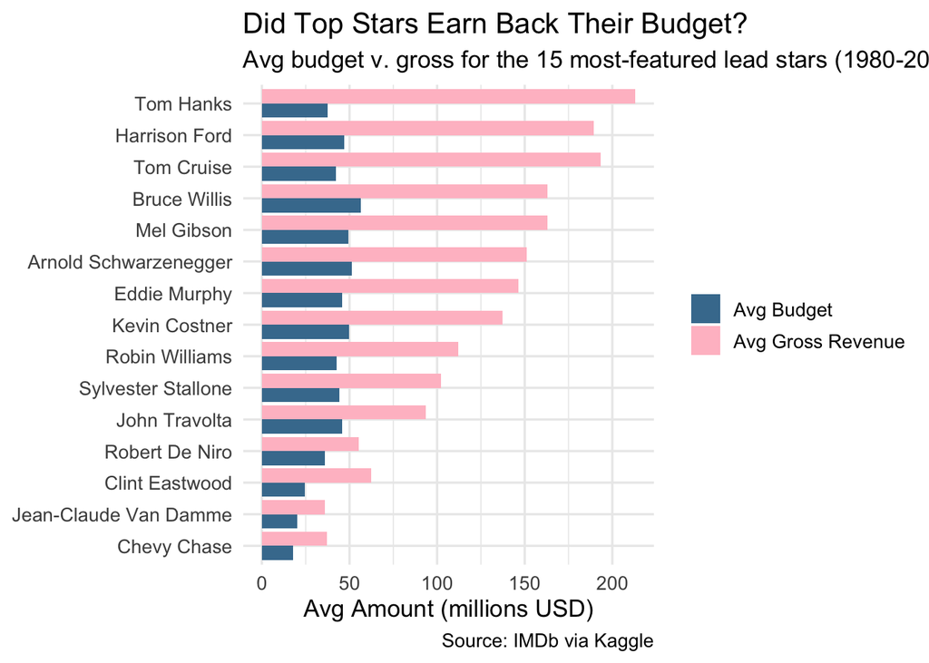

## Step 12: Visualization: And the Award Goes To…

This is our final and most important visualization the one that brings everything together. Every wrangling step we took was building toward this moment. The chart below shows the 15 most frequently cast lead stars from 1980–2001. Bar length shows how many films they led and the color shows their average IMDb score, answering both parts of our question at once.

[figure not shown]

# Conclusion

## What did We Learn?

More appearances does not equal better films. Tom Hanks sits at the top of our chart with the deepest purple bar — the highest average IMDb score of 7.12, while Sylvester Stallone has 23 appearances but one of the lowest average scores. Volume and quality are not the same thing.

## Why Data Wrangling Matters

Data wrangling isn’t just a technical skill it’s how you turn a messy, unusable file into a story worth telling. When we first loaded this dataset, R gave us 3 broken columns and thousands of misread values. By the time we finished, we had uncovered real patterns about power, representation, and quality in Hollywood. Every step we took had a purpose:

readLines() and parse_row() turned an unreadable file into structured data select() focused our attention on what mattered mutate() gave us the right data types and new variables to work with filter() removed noise so our analysis could be trusted count() and summarise() revealed who dominated and how well they performed pivot_longer() reshaped our data so we could visualize it properly

None of the insights from our charts would have been possible without these steps. That is the real power of data wrangling not the functions themselves, but the clarity they create. The next time you open a messy dataset, you now have the tools to turn it into something meaningful.

## References

[Data](https://www.kaggle.com/datasets/ashishkumarjayswal/movies-dataset)

[Clean Data](https://dplyr.tidyverse.org/reference/mutate.html)

[Functions](https://r4ds.had.co.nz/functions.html)

[Scientific Notation](https://stackoverflow.com/questions/5352099/how-can-i-disable-scientific-notation)